# 三角形記法、內角外角與外角定理

> 來源整理：改國二下5_三角形的內角與外角_易讀版.md

## 三角形記法、平角周角、內角外角

> 學習目標：三角形角度題要先把名詞讀對：內角在三角形裡，外角由一邊和另一邊延長線形成。

### 先抓住核心

- 符號 △ 代表三角形，△ABC 讀作三角形 ABC。
- 平角是 180°，周角是 360°；很多角度題最後都會回到這兩個基本量。
- 三角形的三個內角是每個頂點兩邊所夾的角。
- 外角是三角形一邊與另一邊延長線形成的角。
- 每個內角都有兩個相等的外角，因為它們是對頂角或同一個平角的補角。
- 內對角是和某外角頂點不同的兩個內角。

### 解題流程

1. 先標出三個頂點 A、B、C。
2. 圈出三個內角。
3. 延長一邊，找出與內角相鄰成平角的外角。
4. 找外角的兩個內對角：不要選同一頂點的內角。

### 公式、性質與判斷

- **平角**：180°。
- **周角**：360°。
- **內角與相鄰外角**：內角 + 外角 = 180°。

### 例題拆解

- 若 ∠A = 70°，則與 ∠A 相鄰的外角是 110°。
- 若外角在 A 點，則它的內對角是 ∠B 和 ∠C。
- 若一點周圍有三個角，總和常可用 360° 檢查。

### 易錯提醒

- 把外角的內對角誤選成同一頂點的內角。
- 看到圖形外面的角就都叫外角，但外角必須由一邊與另一邊延長線形成。

### 小練一下

- 外角和同頂點內角的關係是相等還是互補？
- 外角的內對角包含同一頂點的內角嗎？

### 記憶鉤子

- 外角要看延長線；內對角要避開外角所在頂點。
- 平角 180°、周角 360° 是這章的兩個地基。

### 圖像化理解

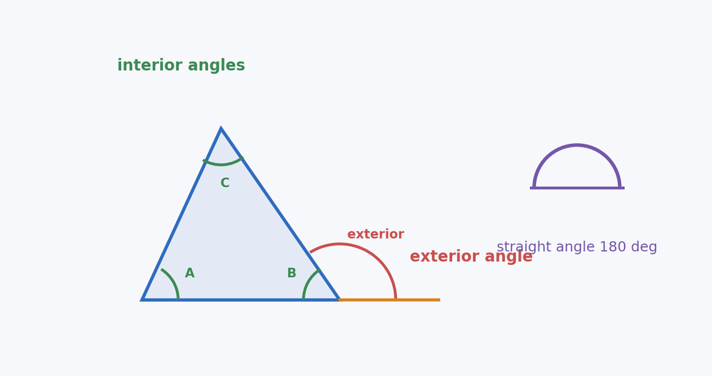

三角形記法、平角周角、內角外角

圖解：用同一個三角形標出內角、外角與內對角，先把名詞位置固定。

## 三角形內角和定理

> 學習目標：任何三角形的三個內角加起來都是 180°。

### 先抓住核心

- 三角形內角和定理：∠A + ∠B + ∠C = 180°。
- 可以過一個頂點作另一邊的平行線，用內錯角把三個角搬到同一直線上。
- 知道兩個角，就能用 180° 減掉它們求第三個角。
- 角度比例題要先把比例總份數加起來，再分配 180°。
- 內角和也是判斷三角形類型的入口：最大角小於 90° 是銳角三角形，等於 90° 是直角三角形，大於 90° 是鈍角三角形。

### 解題流程

1. 先確認題目問的是三角形的內角。
2. 把已知角加起來。
3. 用 180° 減掉已知角總和。
4. 若是比例題，先算總份數，再用每份角度分配。

### 公式、性質與判斷

- **內角和**：A + B + C = 180°。
- **比例分配**：每個角 = 180° * 該角份數 / 總份數。

### 例題拆解

- 若三角形兩角是 58° 和 70°，第三角是 180° - 58° - 70° = 52°。
- 若三內角比為 3:4:5，總份數是 12，每份 15°，三角分別是 45°、60°、75°。
- 45°、60°、75° 三角形三角都小於 90°，所以是銳角三角形。

### 易錯提醒

- 把內角和誤用成 360°。
- 比例題忘記總份數，直接用單一比例分母。

### 小練一下

- 三角形兩角為 35°、65°，第三角是多少？
- 三內角比為 2:3:4，三個角各是多少？

### 記憶鉤子

- 三角形角度題第一反射：三角內角和 180°。
- 比例題先算總份數，不要直接把 180° 除以其中一個數字。

### 圖像化理解

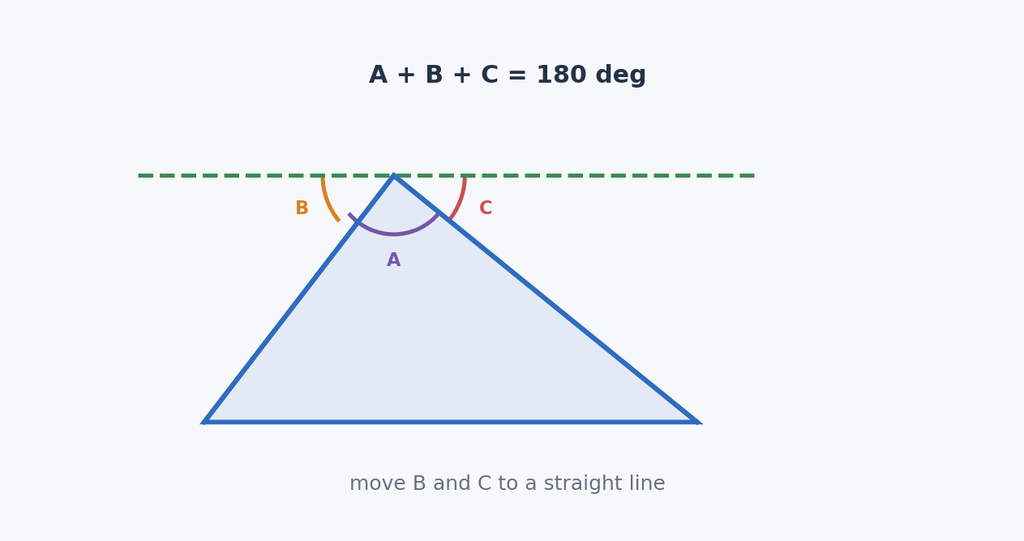

三角形內角和定理

圖解：用過頂點的平行線示意三角形三內角如何拼成一個平角。

## 外角、相鄰內角與外角和

> 學習目標：一個內角和它旁邊的外角形成平角；三角形取一組外角時，外角和是 360°。

### 先抓住核心

- 每個內角與相鄰外角互補，所以內角 + 外角 = 180°。
- 三角形三個內角和是 180°，三組相鄰內外角總共是 540°。
- 因此選三個同方向外角時，外角和是 360°。
- 外角和也可以從『繞圖形轉一圈』理解。
- 路線轉彎題常把內角轉成外角來加總。

### 解題流程

1. 先確認外角是和哪一個內角相鄰。
2. 用 180° - 內角求外角。
3. 若題目問三個外角總和，可直接用 360°。
4. 轉彎題先把彎道內角換成轉角，再加起來。

### 公式、性質與判斷

- **相鄰外角**：外角 = 180° - 內角。
- **三角形外角和**：一組外角總和 = 360°。
- **轉彎角**：常等於 180° - 彎道內角。

### 例題拆解

- 若彎道內角為 120°，轉彎角是 60°。
- 若兩個彎道內角為 120°、100°，共轉 60° + 80° = 140°。
- 若三角形某一內角是 45°，相鄰外角是 135°。

### 易錯提醒

- 把外角和記成 180°。
- 轉彎題直接加內角，忘記船身或路線轉的是外角。

### 小練一下

- 內角 72° 的相鄰外角是多少？
- 三角形三個外角和是多少？

### 記憶鉤子

- 看到『轉了幾度』，常要把內角換成外角。
- 外角和 360° 是一圈，不是三角形裡面的角度總和。

### 圖像化理解

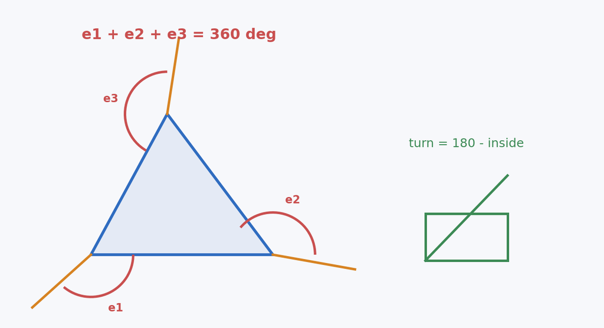

外角、相鄰內角與外角和

圖解：把內角與外角的互補關係，以及三個外角繞一圈的概念放在一起。

## 三角形外角定理

> 學習目標：三角形的一個外角，等於它的兩個內對角之和。

### 先抓住核心

- 外角定理：外角 = 兩個內對角相加。
- 如果外角在 A 點，內對角就是 B、C 兩點的內角。
- 外角定理可以快速處理延長線上的角度題。
- 外角也和相鄰內角互補，因此常能和內角和定理互相轉換。
- 複雜圖形可先找出小三角形，再對每個外角套定理。

### 解題流程

1. 找出外角所在的頂點。
2. 避開同頂點內角，找另外兩個內對角。
3. 建立外角 = 兩個內對角之和。
4. 若已知外角與其中一個內對角，可用減法求另一個。

### 公式、性質與判斷

- **外角定理**：外角 = 兩個內對角之和。
- **同頂點內角**：同頂點內角 + 外角 = 180°。

### 例題拆解

- 若一外角是 110°，其中一個內對角是 75°，另一個內對角是 35°。
- 若外角由 75° 與 35° 兩內對角形成，外角就是 110°。
- 若 ∠2 = 70° - 45°，這是在用外角定理反推內對角。

### 易錯提醒

- 把相鄰內角也拿去相加，誤用外角定理。
- 外角與相鄰內角互補，卻誤以為它們相等。

### 小練一下

- 一個外角為 128°，其中一個內對角為 58°，另一個內對角是多少？
- 外角的兩個內對角會包含相鄰內角嗎？

### 記憶鉤子

- 外角定理一句話：外面一個角，等於遠方兩個角。
- 先避開同頂點內角，再相加。

### 圖像化理解

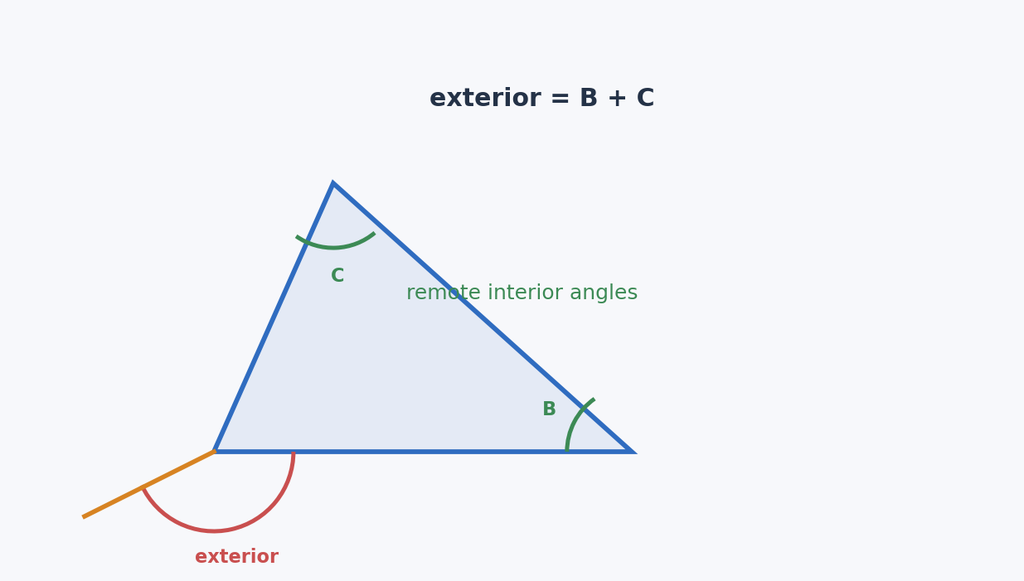

三角形外角定理

圖解：用一個延長邊的三角形標出外角與兩個內對角。